# Prediction Assignment

Anita Robin

13 March 2016

## Background

Using devices such as Jawbone Up, Nike FuelBand, and Fitbit it is now possible to collect a large amount of data about personal activity relatively inexpensively. These type of devices are part of the quantified self movement – a group of enthusiasts who take measurements about themselves regularly to improve their health, to find patterns in their behavior, or because they are tech geeks. One thing that people regularly do is quantify how much of a particular activity they do, but they rarely quantify how well they do it. In this project, our goal will be to use data from accelerometers on the belt, forearm, arm, and dumbell of 6 participants. They were asked to perform barbell lifts correctly and incorrectly in 5 different ways. More information is available from the website here: http://groupware.les.inf.puc-rio.br/har (refer Weight Lifting Exercise Dataset).

Participants were asked to perform one set of 10 repetitions of the Unilateral Dumbbell Biceps Curl in ﬁve diﬀerent fashions: exactly according to the speciﬁcation **(Class A)**, throwing the elbows to the front**(Class B)**, lifting the dumbbell only halfway **(Class C)**, lowering the dumbbell only halfway **(Class D)** and throwing the hips to the front **(Class E)**.

Our aim is to apply suitable machine learning techniques to predict the manner in which they did the exercise.

## The Data

```r
#dimensions of training data
        dim(training)
```

```
## [1] 19622   160
```

```r
#dimensions of test data
        dim(testing)
```

```
## [1]  20 160
```

```r
#closer look at feature set
        colnames(training)[1:10]
```

```
##  [1] "X"                    "user_name"            "raw_timestamp_part_1"
##  [4] "raw_timestamp_part_2" "cvtd_timestamp"       "new_window"
##  [7] "num_window"           "roll_belt"            "pitch_belt"
## [10] "yaw_belt"
```

```r
        colnames(training)[50:60]
```

```
##  [1] "var_accel_arm"    "avg_roll_arm"     "stddev_roll_arm"
##  [4] "var_roll_arm"     "avg_pitch_arm"    "stddev_pitch_arm"
##  [7] "var_pitch_arm"    "avg_yaw_arm"      "stddev_yaw_arm"
## [10] "var_yaw_arm"      "gyros_arm_x"
```

```r
        colnames(training)[100:110]
```

```
##  [1] "amplitude_pitch_dumbbell" "amplitude_yaw_dumbbell"
##  [3] "total_accel_dumbbell"     "var_accel_dumbbell"
##  [5] "avg_roll_dumbbell"        "stddev_roll_dumbbell"
##  [7] "var_roll_dumbbell"        "avg_pitch_dumbbell"
##  [9] "stddev_pitch_dumbbell"    "var_pitch_dumbbell"
## [11] "avg_yaw_dumbbell"
```

```r
        colnames(training)[150:160]
```

```
##  [1] "var_yaw_forearm"  "gyros_forearm_x"  "gyros_forearm_y"
##  [4] "gyros_forearm_z"  "accel_forearm_x"  "accel_forearm_y"
##  [7] "accel_forearm_z"  "magnet_forearm_x" "magnet_forearm_y"
## [10] "magnet_forearm_z" "classe"
```

```r
#The "classe" variable in the training set which is of interest
        summary(training$classe)
```

```
##    A    B    C    D    E
## 5580 3797 3422 3216 3607
```

## Exploratory Data Analysis

### Looking at the sheer volume of data, it is clear that we need to narrow down the potential predictors for our study. A closer look at the features, using the pattern matching capabilities of R, helps us shortlist variables which we can then use for exploratory data analysis using relevant plots.

### To illustrate, we would assume that measurement features pertaining to forearm/arm will have a higher influence on classification between Class A (the correct way)and Class B(common mistake of putting elbows to the front). Lets do a quick data analysis to check this.

```
##  [1] "roll_arm"                "pitch_arm"
##  [3] "yaw_arm"                 "total_accel_arm"
##  [5] "var_accel_arm"           "avg_roll_arm"
##  [7] "stddev_roll_arm"         "var_roll_arm"
##  [9] "avg_pitch_arm"           "stddev_pitch_arm"
## [11] "var_pitch_arm"           "avg_yaw_arm"
## [13] "stddev_yaw_arm"          "var_yaw_arm"
## [15] "gyros_arm_x"             "gyros_arm_y"
## [17] "gyros_arm_z"             "accel_arm_x"
## [19] "accel_arm_y"             "accel_arm_z"
## [21] "magnet_arm_x"            "magnet_arm_y"
## [23] "magnet_arm_z"            "kurtosis_roll_arm"
## [25] "kurtosis_picth_arm"      "kurtosis_yaw_arm"
## [27] "skewness_roll_arm"       "skewness_pitch_arm"
## [29] "skewness_yaw_arm"        "max_roll_arm"
```

[output cut: 23 more lines]

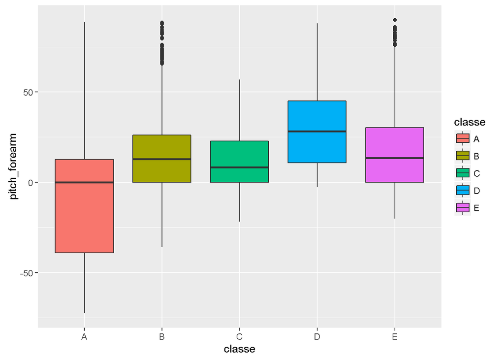

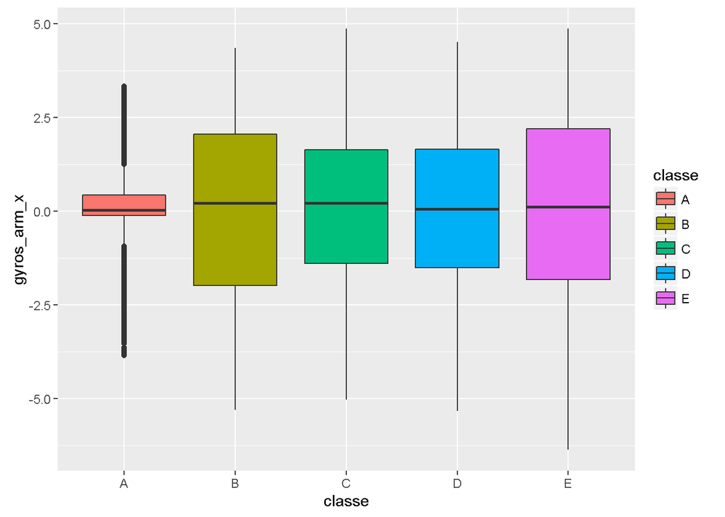

## Machine Learning Technique

### Looking at the above, it seems that **an approach involving a step by step binary classification between class A vs. each of the other classes** may yield us a list of variables that we can use to finally train our final model for classifying the data.

### To check the feasibilty of the above approach, we generated a subset of the data to include only the variables of interest(using exploratory data plots, not included in this document, in the interest of brevity). Then we further split up data into training and test(for cross validation). A look at the accuracy on the taining and cross validation set will help us decide in favour of/against this approach. We plan to use random forest to train our classifier since its the most efficient one for non linear settings.

```
## Random Forest
##
## 7033 samples
##   10 predictor
##    2 classes: 'A', 'B'
##
## No pre-processing
## Resampling: Cross-Validated (10 fold)
## Summary of sample sizes: 6330, 6330, 6329, 6330, 6330, 6329, ...
## Resampling results across tuning parameters:
##
##   mtry  Accuracy   Kappa      Accuracy SD  Kappa SD
##    2    0.9732696  0.9442053  0.008543601  0.01796725
##    6    0.9736961  0.9451190  0.007584142  0.01599874
##   10    0.9705679  0.9386599  0.009732676  0.02044544
##
## Accuracy was used to select the optimal model using  the largest value.
## The final value used for the model was mtry = 6.
```

```
## [1] 0.9756826
```

```
##                   accel_dumbbell_x accel_dumbbell_y magnet_dumbbell_x
## accel_dumbbell_x       1.000000000      -0.38807857        0.45045612
## accel_dumbbell_y      -0.388078570       1.00000000       -0.27973342
## magnet_dumbbell_x      0.450456124      -0.27973342        1.00000000
## gyros_arm_x           -0.007760535       0.05114772       -0.06740180
## gyros_arm_y           -0.061557079      -0.00652303        0.03089107
## pitch_arm             -0.186039434       0.13950311       -0.07535206
## pitch_forearm          0.465770148      -0.17869070        0.37630963
## magnet_forearm_x      -0.139214332       0.08168814       -0.16301584
## magnet_forearm_y      -0.195785992      -0.02997228       -0.03091598
## accel_forearm_x       -0.301641590       0.11727497        0.04940618
##                    gyros_arm_x gyros_arm_y    pitch_arm pitch_forearm
## accel_dumbbell_x  -0.007760535 -0.06155708 -0.186039434     0.4657701
## accel_dumbbell_y   0.051147718 -0.00652303  0.139503113    -0.1786907
## magnet_dumbbell_x -0.067401801  0.03089107 -0.075352062     0.3763096
## gyros_arm_x        1.000000000 -0.91783699  0.014818355    -0.1003966
## gyros_arm_y       -0.917836989  1.00000000  0.018855807     0.0248260
## pitch_arm          0.014818355  0.01885581  1.000000000    -0.1896154
## pitch_forearm     -0.100396592  0.02482600 -0.189615429     1.0000000
## magnet_forearm_x  -0.083727427  0.10124769  0.041271939    -0.4497371
## magnet_forearm_y   0.346816046 -0.27450525 -0.015289515    -0.3324655
## accel_forearm_x    0.018969521  0.10378260 -0.006404213    -0.5033722
##                   magnet_forearm_x magnet_forearm_y accel_forearm_x
## accel_dumbbell_x       -0.13921433      -0.19578599    -0.301641590
## accel_dumbbell_y        0.08168814      -0.02997228     0.117274971
## magnet_dumbbell_x      -0.16301584      -0.03091598     0.049406183
## gyros_arm_x            -0.08372743       0.34681605     0.018969521
## gyros_arm_y             0.10124769      -0.27450525     0.103782598
## pitch_arm               0.04127194      -0.01528952    -0.006404213
## pitch_forearm          -0.44973710      -0.33246553    -0.503372226
## magnet_forearm_x        1.00000000      -0.23076674     0.671371460
## magnet_forearm_y       -0.23076674       1.00000000     0.285910628
## accel_forearm_x         0.67137146       0.28591063     1.000000000
```

```r
###class C
#pattern matching for columns containing dumbbell
        l<-grep("dumbbell",colnames(training))

#getting the relevant column names
        colnames(training[grep("dumbbell",colnames(training))])

#exploratory plots
        p <- ggplot(data=training, aes(classe,yaw_dumbbell))
        p + geom_boxplot(aes(fill =classe))

#subsetting the data
        trainings<-training[training$classe %in% c("A","C"),
                    c("accel_dumbbell_x","accel_dumbbell_y",
                      "magnet_dumbbell_x","roll_dumbbell",
                      "yaw_dumbbell","classe")]
        trainings$classe=factor(trainings$classe)
        inTrain = createDataPartition(trainings$classe, p = 3/4)[[1]]
        train = trainings[ inTrain,]
        test = trainings[ -inTrain,]
#building the classifier
        modFit2 <- train(classe ~.,
                method = "rf",
                data=train,
                verbose = FALSE,
                trControl=trainControl(method="cv"),number=3
)
#predictions and accuracy
        pred1<-predict(modFit2,test)
        test$rightPred <- (pred1 == test$classe)
        accuracy <- sum(test$rightPred)/nrow(test)
        accuracy

#Repeat for class D

#subsetting for training and validation set
        trainings<-training[training$classe %in% c("A","D"),
                    c("accel_dumbbell_x","accel_dumbbell_y",
                      "magnet_dumbbell_x","roll_dumbbell",
                      "yaw_dumbbell","classe")]
        trainings$classe=factor(trainings$classe)
        inTrain = createDataPartition(trainings$classe, p = 3/4)[[1]]
        train = trainings[ inTrain,]
        test = trainings[ -inTrain,]

#training the classifier
        modFit3 <- train(classe ~.,
                 method = "rf",
                 data=train,
                 verbose = FALSE,
                 trControl=trainControl(method="cv"),number=3
)
#testing the accuracy
        pred1<-predict(modFit3,test)
        test$rightPred <- (pred1 == test$classe)
        accuracy <- sum(test$rightPred)/nrow(test)
        accuracy

#Repeat for class E

 #pattern matching for columns containing belt
        l<- grep("belt",colnames(training))

#exploratory plots
        p <- ggplot(data=training, aes(classe,magnet_belt_z))
        p + geom_boxplot(aes(fill =classe))

#subsetting the data
        trainings<-training[training$classe %in% c("A","E"),
                    c("accel_belt_x","accel_belt_y","accel_belt_z",
                      "roll_belt","pitch_belt","yaw_belt",
                      "magnet_belt_z","magnet_belt_x",
                      "magnet_belt_y","classe")]
        trainings$classe=factor(trainings$classe)
        inTrain = createDataPartition(trainings$classe, p = 3/4)[[1]]
        train = trainings[ inTrain,]
        test = trainings[ -inTrain,]
#checking for correlations
        cor(trainings[sapply(trainings, function(x) !is.factor(x))])
#building the model
        modFit4 <- train(classe ~.,
                 method = "rf",
                 data=train,
                 verbose = FALSE,
                 trControl=trainControl(method="cv"),number=3
        )
#testing the accuracy
        pred1<-predict(modFit4,test)
        test$rightPred <- (pred1 == test$classe)
        accuracy <- sum(test$rightPred)/nrow(test)
        accuracy
```

[output not shown]

## Final model selection

### We will now combine all above models by including all the predictors used and train the model ,once again, using random forest with cross validation, on our original training dataset which has been split into training and test(for validation).

```r
#original training set - omit nas
        set.seed(1234)
        training[is.na(training)] <- 0
        inTrain = createDataPartition(training$classe, p = 3/4)[[1]]
        train = training[ inTrain,]
        test = training[ -inTrain,]

#building the model with combined predictors
        finalModel <- train(classe ~ accel_belt_x+accel_belt_y+accel_belt_z+
                 roll_belt+pitch_belt+yaw_belt+
                 magnet_belt_z+magnet_belt_x+
                 magnet_belt_y+accel_dumbbell_x+accel_dumbbell_y+
                 magnet_dumbbell_x+gyros_arm_x+gyros_arm_y+
                 pitch_arm+pitch_forearm+magnet_forearm_x+
                 magnet_forearm_y+accel_forearm_x+
                 roll_dumbbell+yaw_dumbbell,
                method = "rf",
                data=train,
                verbose = FALSE,
                trControl=trainControl(method="cv"),number=3
                )
#using the final model to test predictions against our validation set
        pred1<-predict(finalModel,test)
        test$rightPred <- (pred1 == test$classe)
        accuracy <- sum(test$rightPred)/nrow(test)

#Accuracy of the classifier
        accuracy
```

```
## [1] 0.9842985
```

```r
#Final model
        finalModel
```

[output not shown]